# getting TCGA COAD Methylation and Expression data from cBioportal

# Introduction

The analysis of L shaped genes performed elsewhere (“Informe_v12.2_L-Shape_Selection_Pipeline.Rnw”) has used data obtained from TCGA and provided by the researcher.

These data have shown a surprisingly low number of L-shaped genes when they have been processed with the *heuristic* algorithm. Before reviewing the algorithm or its parameters we have wanted to check if the data have been properly processed.

With this aim in mind we have obtained the data from the cBioportal and processed them in a `reasonable’ way.

```r
source("Rcode/usefulFunctions.R")
```

# Obtaining the data

The datasets have been downloaded from the cBioportal web site and consist of the “tumor-only” data from the Nature 2012 study.

## Expression data

```r
x<- data_expression_merged_median_Zscores <- read.delim("dades/gdac.20160128.cBioportal/coadread_tcga_pub/data_expression_merged_median_Zscores.txt",sep="\t", head = TRUE)
DimMat(x, "Expression data")
```

```
First rows and columns
  Entrez_Gene_Id TCGA.A6.2670 TCGA.A6.2672 TCGA.A6.2674 TCGA.A6.2676
1           6205      -0.3558       0.9810      -1.2011       0.9000
2           9240      -0.4357       1.3534       1.1311       2.7849
3           4313       1.9436       0.9944       3.2631      -0.8883
4         118611       0.2938      -1.2223      -0.6092      -0.7407
5          23051       0.1557       0.2268       2.4051      -1.1417
6           2073       1.5886       2.1599       2.5763      -0.1131

Last rows first columns
      Entrez_Gene_Id TCGA.A6.2670 TCGA.A6.2672 TCGA.A6.2674 TCGA.A6.2676
17781    hsa-miR-653       0.3125      -1.4160       0.9391       0.2015
17782 hsa-miR-542-3p       0.9243      -0.3159       0.5633      -1.4600
17783    hsa-miR-744      -0.5772      -2.4297       0.6828      -1.5683
17784   hsa-miR-744*      -0.8994      -1.5494      -0.4266      -0.3811
17785   hsa-miR-374b      -0.2753      -1.6204      -0.0505      -1.0873
17786    hsa-miR-664       0.6066       0.0449       1.2186      -0.2077
```

The first column contains Entrez identifiers which may be used (if unique) as row names. However it also contains miRNA identifiers (“hsa-*“) showing that the last rows are not gene expression but microRNAs expression values. These are removed from the dataset

```r
sum(duplicated(x$Entrez_Gene_Id))
```

```
[1] 0
```

```r
rownames(x) <- expresEntrez<- x$Entrez_Gene_Id
if(ncol(x)==225) x<- x[,-1]
miRNAs <- grep("hsa-*", rownames(x))
x <- x[-miRNAs,]
DimMat(x)
```

```
First rows and columns
       TCGA.A6.2670 TCGA.A6.2672 TCGA.A6.2674 TCGA.A6.2676 TCGA.A6.2677
6205        -0.3558       0.9810      -1.2011       0.9000      -0.1387
9240        -0.4357       1.3534       1.1311       2.7849      -0.3527
4313         1.9436       0.9944       3.2631      -0.8883      -1.4257
118611       0.2938      -1.2223      -0.6092      -0.7407       0.1848
23051        0.1557       0.2268       2.4051      -1.1417       0.0739
2073         1.5886       2.1599       2.5763      -0.1131      -0.1758

Last rows first columns
       TCGA.A6.2670 TCGA.A6.2672 TCGA.A6.2674 TCGA.A6.2676 TCGA.A6.2677
122042      -1.0768      -1.9185       0.4920      -0.6986       0.6908
113791       2.6684       0.5805       0.1631      -1.6714      -0.5716
25800       -1.0579       0.3358      -0.4029      -0.7341      -1.2276
6633        -0.3276      -0.6036      -0.5753       1.2459       0.0553
364          1.8823      -1.5395      -0.1225      -0.4081       2.4561
1075         0.4352       0.3916       1.1339       1.1667      -1.0711
```

Entrez identifiers are good for indexing but may be confusing as row names, and they are not informative about the gene. They are converted into HuGO symbols.

```r
require(Homo.sapiens)
anotacs<- select(Homo.sapiens, keys=rownames(x), columns= "SYMBOL", keytype="ENTREZID")
DimMat(anotacs, "Entrez and HuGO identifiers",2)
```

[output not shown]

Some Entrezs are not associated with gene symbols.

```r
 head(anotacs[is.na(anotacs[,2]),])
```

|  | ENTREZID | SYMBOL |
| --- | --- | --- |
| 155 | 389102 | NA |
| 282 | 117153 | NA |
| 890 | 442092 | NA |
| 2264 | 26148 | NA |
| 3505 | 728404 | NA |
| 3584 | 641590 | NA |

These genes are removed and then the remaining gene symbols (uniquely associated with Entrez Ids) are used as rownames. before doing the assignment NAs are removed from the Symbols list.

```r
Entrez_without_Symbol<- is.na(anotacs[,2])
x<- x[!Entrez_without_Symbol,]
anotacs<- anotacs[!Entrez_without_Symbol,]
rownames(x) <-anotacs[,2]
DimMat(x)
```

[output not shown]

The resulting matrix has many genes with all values set to NA and a few genes with a few NAs. Genes with more than 75% NAs are removed.

```r
dim(expres2Keep)
```

```
[1] 16609   224
```

## Methylation Data

Methylation data are processed similarly

```r
y <- data_methylation_hm27 <- read.delim("dades/gdac.20160128.cBioportal/coadread_tcga_pub/data_methylation_hm27.txt", sep="\t", head = TRUE)
DimMat(y)
```

```
First rows and columns
  Hugo_Symbol Entrez_Gene_Id TCGA.A6.2670 TCGA.A6.2672 TCGA.A6.2674
1       MEOX2           4223   0.04982367   0.35746202  0.184220217
2       IMPA2           3613   0.01682225   0.01740079  0.013319633
3        TTC8         123016   0.01319039   0.01489892  0.008213065
4      RNASE4           6038   0.01984625   0.02053177  0.009412528
5      RETSAT          54884   0.01388989   0.02328967  0.020388271
6        RHOC            389   0.38923577   0.54485601  0.619743443

Last rows first columns
      Hugo_Symbol Entrez_Gene_Id TCGA.A6.2670 TCGA.A6.2672 TCGA.A6.2674
12323       SOCS3           9021   0.67606511   0.60749909  0.510949402
12324        PIGB           9488   0.06151185   0.07704584  0.068706949
12325      TM9SF4           9777   0.94631061   0.90674934  0.918775750
12326    C11orf24          53838   0.02349327   0.06619018  0.030738025
12327        RPN1           6184   0.01040462   0.01595457  0.009128334
12328       CYB5A           1528   0.01598729   0.02243034  0.015293776
```

Check that each gene has a unique entrez or gene symbol associated, alternatively remove duplicates.

```r
dim(y)
```

```
[1] 12312   238
```

Instead of relying on the provided HuGO symbols table Entrezs are converted again into Gene Symbols to avoid problems due to synonims.

```r
length(setdiff(y$Hugo_Symbol,anotacs[,2]))
```

```
[1] 910
```

```r
DimMat(y)
```

```
First rows and columns
       TCGA.A6.2670 TCGA.A6.2672 TCGA.A6.2674 TCGA.A6.2676 TCGA.A6.2677
MEOX2    0.04982367   0.35746202  0.184220217   0.21128648   0.03121908
IMPA2    0.01682225   0.01740079  0.013319633   0.01673485   0.01665023
TTC8     0.01319039   0.01489892  0.008213065   0.01556728   0.01131672
RNASE4   0.01984625   0.02053177  0.009412528   0.38137048   0.02431166
RETSAT   0.01388989   0.02328967  0.020388271   0.01426849   0.01924375
RHOC     0.38923577   0.54485601  0.619743443   0.45574632   0.23664723

Last rows first columns
         TCGA.A6.2670 TCGA.A6.2672 TCGA.A6.2674 TCGA.A6.2676 TCGA.A6.2677
SOCS3      0.67606511   0.60749909  0.510949402   0.64452487   0.61841597
PIGB       0.06151185   0.07704584  0.068706949   0.09270812   0.11856287
TM9SF4     0.94631061   0.90674934  0.918775750   0.92023460   0.90830325
C11orf24   0.02349327   0.06619018  0.030738025   0.05764103   0.06156388
RPN1       0.01040462   0.01595457  0.009128334   0.01525132   0.02067705
CYB5A      0.01598729   0.02243034  0.015293776   0.05253587   0.03828965
```

```r
dim(mets2Keep)
```

```
[1] 12306   236
```

# Matching gene expression and methylation values

In order to make it possible to associate expression and methylation data we keep only common genes and common samples between the two datasets and sort genes and samples aplphabetically.

```r
sum(rownames(commonMets)==rownames(commonExpres))
```

```
[1] 11788
```

## Missing values imputation in matched datasets

Some calculations do not allow missing values but there are a few left.

```r
# revisem els NAs
quantsNAs_expr <- countNAs(commonExpres)
table(quantsNAs_expr)
quantsNAs_mets <- countNAs(commonMets)
table(quantsNAs_mets)
```

[output not shown]

Given that the number of missings is very small we decide to impute them using a kNN approach.

```r
# Com son pocs podem imputar-los
require(impute)
set.seed(123456)
imputed.commonExpressions <- impute.knn(as.matrix(commonExpres))
```

[output not shown]

```r
commonExpressions <- imputed.commonExpressions [["data"]]
DimMat(commonExpressions, "TCGA Microarray data (font cBioportal) : ")
```

```
First rows and columns
       TCGA.A6.2670 TCGA.A6.2672 TCGA.A6.2674 TCGA.A6.2676 TCGA.A6.2677
A1BG        -0.2146       0.0955       0.4330      -0.1106      -0.9332
A2M          0.8178      -0.1002       0.9305      -0.0978      -0.6882
A2ML1       -2.4996      -0.5769      -0.3028       1.8604      -0.5632
A4GALT       0.6284       0.1752       2.0181      -0.2530       0.7215
A4GNT       -1.2978       1.0514       0.0650       0.9024      -0.0558
AAAS        -1.4268      -0.5235      -0.6601       0.8645      -0.7735

Last rows first columns
       TCGA.A6.2670 TCGA.A6.2672 TCGA.A6.2674 TCGA.A6.2676 TCGA.A6.2677
ZSWIM1       4.0005      -0.2083      -0.4331      -0.1014       2.0857
ZW10         1.0345       0.2124      -2.6645       0.6095       1.7776
ZWINT       -1.0292       0.5560      -0.2960       2.2055       0.7068
ZYX          2.1916       1.1821       0.7318       0.6979      -0.7969
ZZEF1       -0.9266       0.6559       0.0685       0.5770      -2.7634
ZZZ3        -0.3863      -2.1836      -2.0220      -0.2727       2.2780
```

```r
set.seed(123456)
imputed.commonMethylations <- impute.knn(as.matrix(commonMets))
```

[output not shown]

```r
commonMethylations <- imputed.commonMethylations[["data"]]
DimMat(commonMethylations,"TCGA Methylation data (font cBioportal) : ")
```

```
First rows and columns
       TCGA.A6.2670 TCGA.A6.2672 TCGA.A6.2674 TCGA.A6.2676 TCGA.A6.2677
A1BG      0.9885513    0.9884264    0.9863417    0.9929678    0.9564511
A2M       0.7721959    0.7733813    0.6672026    0.7681240    0.4288545
A2ML1     0.3114797    0.6566719    0.5955558    0.3286172    0.2230512
A4GALT    0.4284274    0.5694785    0.3273814    0.6272344    0.4968013
A4GNT     0.3193884    0.7374202    0.6263214    0.4070668    0.6685441
AAAS      0.1023682    0.1342126    0.1013553    0.1543296    0.1173770

Last rows first columns
       TCGA.A6.2670 TCGA.A6.2672 TCGA.A6.2674 TCGA.A6.2676 TCGA.A6.2677
ZSWIM1   0.01506668   0.02431391   0.02888446   0.06169009   0.02743826
ZW10     0.01694188   0.02066602   0.01237340   0.01510791   0.01474830
ZWINT    0.02145952   0.02822439   0.02528438   0.02537047   0.03017823
ZYX      0.01377679   0.01942471   0.01705289   0.02043826   0.02033439
ZZEF1    0.04174156   0.04988478   0.04155283   0.06714544   0.05799813
ZZZ3     0.01589339   0.02888570   0.01542681   0.01594606   0.02646809
```

## Comparing data with values provided by the researcher

A previous version of these data had been provided by the researcher

```r
DimMat(commonExpressions, "TCGA Microarray data (font cBioportal) : ")
```

[output not shown]

In order to make them comparable, commonExpressions and commonMetilations column names are renamed to match the others’ datasets

```r
length(intersect(rownames(commonExpressions), rownames(TCGAExprData)))
```

```
[1] 9834
```

Datasets can be plotted (via PCA) to look for potential batch effects

```r
source("https://raw.githubusercontent.com/alexsanchezpla/usefulFunctions/master/plotPCA2.R")
```

```r
opt<- par(mfrow=c(2,1))
plotPCA2(commonExpressions, scale=TRUE, transpose=TRUE, dataDesc = "Expression data from cBioportal" )
plotPCA2(TCGAExprData, scale=TRUE, transpose=TRUE, dataDesc = "Expression data from DA" )
par(opt)
```

[output not shown]

```r
opt<- par(mfrow=c(2,1))
plotPCA2(commonMethylations, scale=FALSE, transpose=TRUE, dataDesc = "Methylation data from cBioportal" )
plotPCA2(TCGAMetilData, scale=FALSE, transpose=TRUE, dataDesc = "Methylation data from DA" )
```

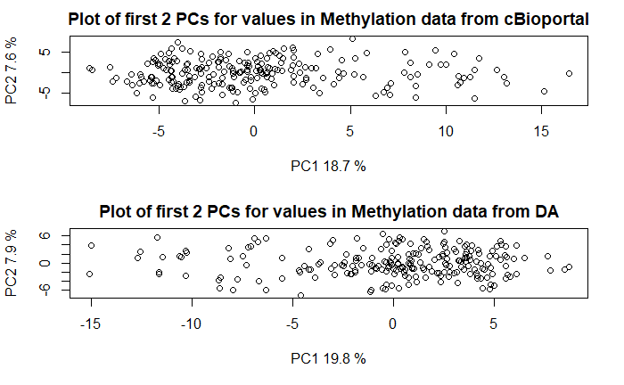

```r
par(opt)
```

The distributions can also be compared using boxplots

```r
minY<- min(min(commonExpressions),min(TCGAExprData))
maxY <- max(max(commonExpressions),max(TCGAExprData))
opt<- par(mfrow=c(2,1))
boxplot(as.data.frame(commonExpressions), las=2, main = "Expression data from cBioportal", ylim=c(minY, maxY), cex.axis=0.6 )
boxplot(as.data.frame(TCGAExprData), las=2, main  = "Expression data from DA", ylim=c(minY, maxY),  cex.axis=0.6 )
```

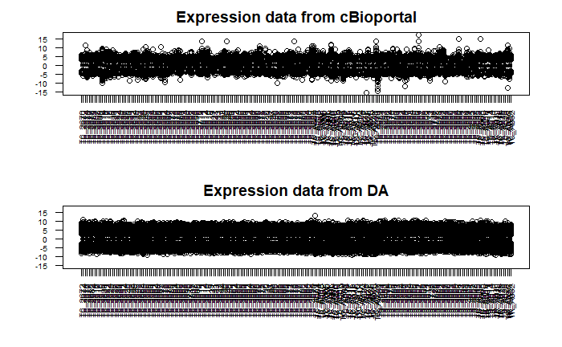

```r
par(opt)
```

```r
minY<- min(min(commonMethylations),min(TCGAMetilData))
maxY <- max(max(commonMethylations),max(TCGAMetilData))
opt<- par(mfrow=c(2,1))
boxplot(as.data.frame(commonMethylations), las=2, main = "Methylation data from cBioportal", ylim=c(minY, maxY), cex.axis=0.4 )
boxplot(as.data.frame(TCGAMetilData), las=2, main  = "Methylation data from DA", ylim=c(minY, maxY),  cex.axis=0.4 )
```

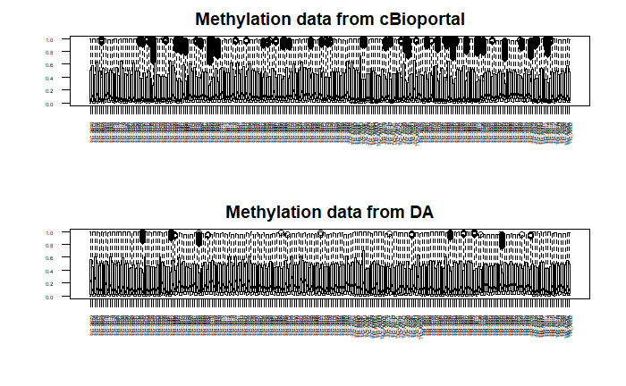

```r
par(opt)
```

[figure not shown]

```r
opt<- par(mfrow=c(2,1))
plot(density(commonMethylations), main= "Methylation data from cBioportal" )
plot(density(TCGAMetilData),"Methylation data from DA" )
```

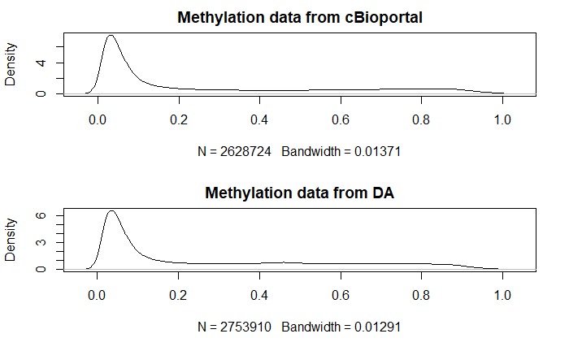

```r
par(opt)
```